# Entrega 2 - Data Challenge: Previsão de Probabilidade de Default (PD)

Thais Teixeira

03/04/2021

# Manipulação de Dados e Data Wrangling

## 1 - Sumário do Dataset de Treino

```r
#Dimensão do Dataset de Treino
dim(train.parquet)
```

```
## [1] 2889113      15
```

```r
#Avaliando a estrutura de dados do dataset
str(train.parquet)
```

```
## tibble [2,889,113 x 15] (S3: tbl_df/tbl/data.frame)
##  $ id                          : num [1:2889113] 6 6 6 6 6 6 6 6 6 6 ...
##  $ desembolso                  : POSIXct[1:2889113], format: "2019-03-24 21:00:00" "2019-03-24 21:00:00" ...
##  $ vencimento                  : POSIXct[1:2889113], format: "2019-12-25 21:00:00" "2019-12-25 21:00:00" ...
##  $ valor_emprestado            : num [1:2889113] 7100 7100 7100 7100 7100 7100 7100 7100 7100 7100 ...
##  $ pgto_diario_esperado        : num [1:2889113] 33.7 33.9 33.9 33.9 33.9 ...
##  $ dia                         : POSIXct[1:2889113], format: "2019-03-24 21:00:00" "2019-03-25 21:00:00" ...
##  $ dias_pos_desembolso         : num [1:2889113] 0 1 2 3 4 5 6 7 8 9 ...
##  $ divida_total                : num [1:2889113] 7198 7212 7227 7207 7222 ...
##  $ divida_principal            : num [1:2889113] 7100 7100 7100 7100 7100 7100 7100 7100 7100 7100 ...
##  $ pagamento_diario            : num [1:2889113] 0 0 0 33.6 0 ...
##  $ amortizacao_principal_diario: num [1:2889113] 0 0 0 0 0 0 0 0 0 0 ...
##  $ transacionado               : num [1:2889113] 664 0 150 0 0 0 0 736 120 218 ...
##  $ subsegmento                 : chr [1:2889113] NA NA NA NA ...
##  $ y                           : num [1:2889113] 0 0 0 0 0 0 0 0 0 0 ...
##  $ __index_level_0__           : int [1:2889113] 3281 3282 3283 3284 3285 3286 3287 3288 3289 3290 ...
```

```r
#Descrição do Dataset
describe(train.parquet)
```

```
## train.parquet
##
##  15  Variables      2889113  Observations
## --------------------------------------------------------------------------------
## id
##        n  missing distinct     Info     Mean      Gmd      .05      .10
##  2889113        0    17344        1    29534    19808     2577     5073
##      .25      .50      .75      .90      .95
##    14446    30657    44396    52180    55156
##
## lowest :     6     8     9    11    12, highest: 59428 59431 59433 59438 59443
## --------------------------------------------------------------------------------
## desembolso
##          n    missing   distinct       Info       Mean        Gmd        .05
##    2889113          0        459          1 2020-01-27   11306286 2019-07-10
##        .10        .25        .50        .75        .90        .95
## 2019-09-02 2019-11-06 2020-01-24 2020-04-17 2020-06-29 2020-07-29
##
## lowest : 2019-02-28 2019-03-06 2019-03-08 2019-03-11 2019-03-12
## highest: 2021-02-09 2021-02-11 2021-02-18 2021-02-23 2021-02-25
## --------------------------------------------------------------------------------
## vencimento
##          n    missing   distinct       Info       Mean        Gmd        .05
##    2889113          0        829          1 2020-12-26   18726968 2020-04-07
##        .10        .25        .50        .75        .90        .95
## 2020-05-30 2020-08-04 2020-10-23 2021-07-10 2021-10-01 2021-11-14
##
## lowest : 2019-11-29 2019-12-05 2019-12-09 2019-12-10 2019-12-11
## highest: 2022-10-18 2022-10-24 2022-10-25 2022-11-12 2022-11-13
## --------------------------------------------------------------------------------
## valor_emprestado
##        n  missing distinct     Info     Mean      Gmd      .05      .10
##  2889113        0     8182        1    13161    14026     1253     1885
##      .25      .50      .75      .90      .95
##     3600     7900    16120    31000    46397
##
## lowest :    100.01    101.00    104.00    110.00    150.00
## highest: 129777.00 148272.00 150000.00 159000.00 212992.00
## --------------------------------------------------------------------------------
## pgto_diario_esperado
```

[output cut: 76 more lines]

```
## --------------------------------------------------------------------------------
## y
##        n  missing distinct     Info      Sum     Mean      Gmd
##  2889113        0        2    0.206   214089   0.0741   0.1372
##
## --------------------------------------------------------------------------------
## __index_level_0__
##        n  missing distinct     Info     Mean      Gmd      .05      .10
##  2889113        0  2889113        1  8765917  6685638   862062  1561751
##      .25      .50      .75      .90      .95
##  3989334  7984427 12504048 17089069 19850885
##
## lowest :     3281     3282     3283     3284     3285
## highest: 29330789 29337013 29337015 29337017 29337019
## --------------------------------------------------------------------------------
```

É possível observar que o dataset de treino (`train.parquet`), a variável `subsegmento` possui missing values, `NA`.

Nestes casos, iremos classificá-los como `Sem Classificação`.

Além disso, iremos formartar as variáveis de `Date` (`as.Date`) e a variável `y`, a qual apresenta quais ID’s quitaram antes do vencimento `0` ou não `1` como `Factor` (`as.factor`).

## 2 - Limpeza e Formatação do Train DB (train.parquet)

Como temos interesse em predizer no dia 90 do contrato de crédito a probabilidade do cliente não quitar a dívida até o vencimento. Devemos filtrar `train.parquet` de forma a selecionar somente os 90 primeiros dias de contrato `train_90`.

```r
dim(train_90)
```

```
## [1] 1461799      15
```

## 3 - Análise Exploratória de Dados - Inicial

### 3.1 - Análise Univariada

#### 3.1.1 - Variáveis Qualitativas

##### A - SUBSEGMENTO

Como apresentado pelo número de subsegmentos e confirmado pelo gráfico abaixo:

- Há muitos subsegmentos, então é provável que eles não influenciem a quitação do crédito dentro do prazo ou não.

```r
#Quantos subsegmentos temos em nosso train dataset?
length(unique(train.parquet$subsegmento))
```

```
## [1] 74
```

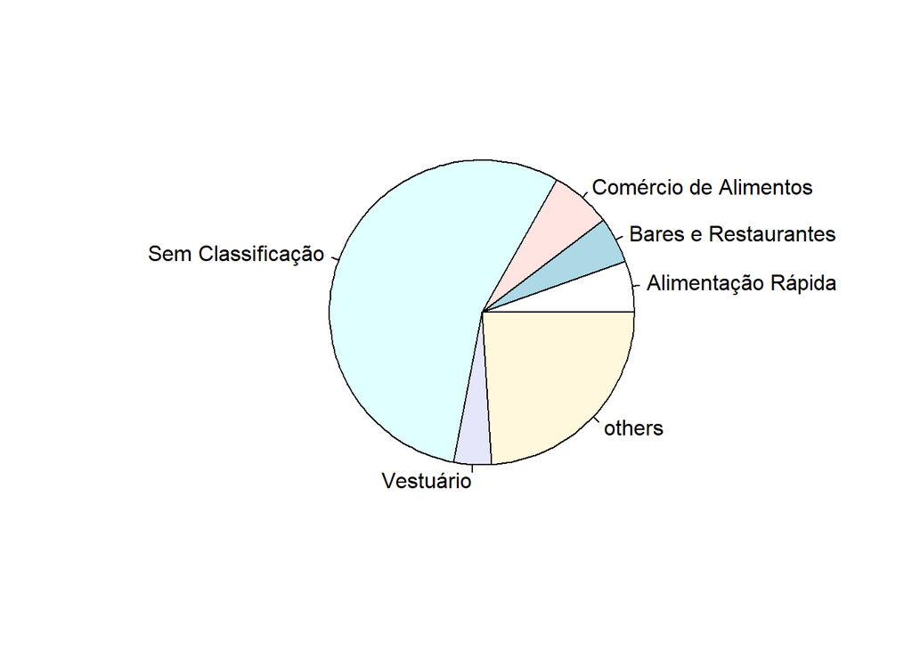

##### B - DEFAULT

A distribuição dos dados de default se apresentam da seguinte maneira (variável `y`):

- Somente 4.4% do train dataset não quitou a dívida dentro do prazo estabelecido

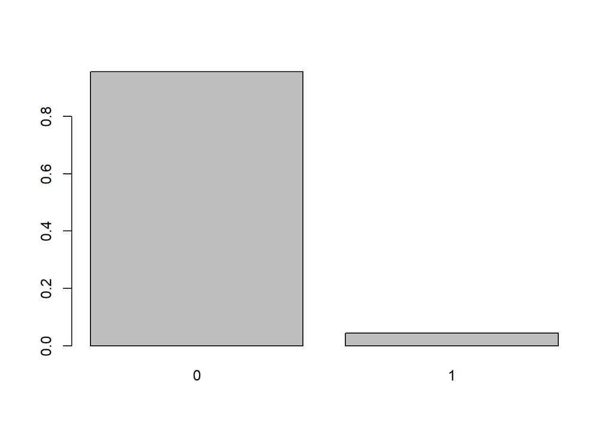

```
##
##          0          1
## 0.95571956 0.04428044
```

#### 3.1.1 - Variáveis Quantitativas

É possível observar dos gráficos a seguir que:

- A maior parte dos empréstimos se concentram no intervalo de valores até 20k e, por consequência;
- A maior parte dos pagamentos diários estão distribuídos em *“parcelas diárias”* de até 100 reais/dia

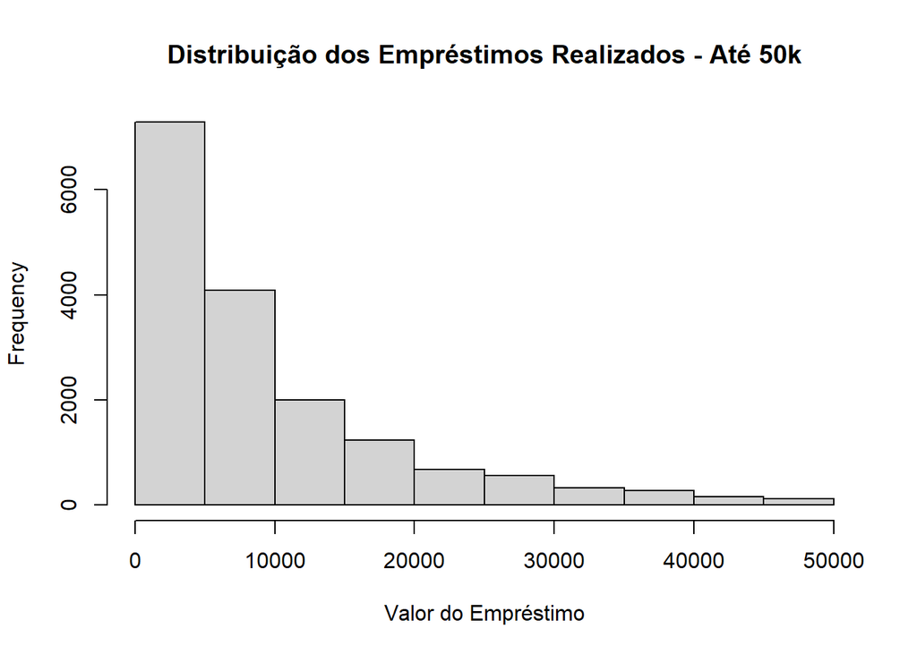

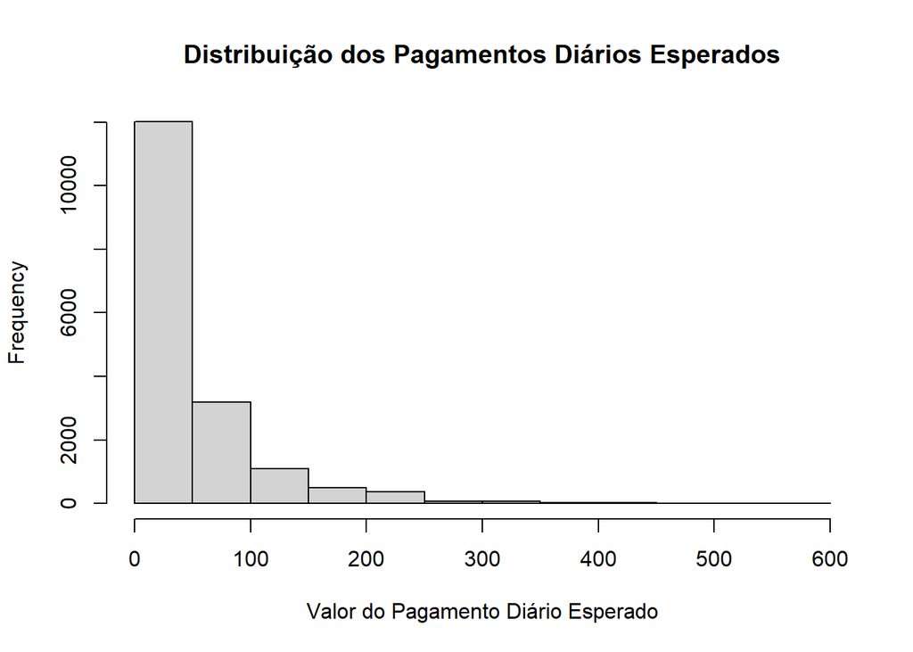

### 3.2 - Análise Bivariada

#### 3.2.1 - Variáveis Qualitativas & Quantitativas

##### A - DEFAULT & VALOR DO EMPRÉSTIMO

Pelo gráfico a seguir, é possível verificar que o valor do empréstimo dos que **não** quitaram a dívida é **menor** do que o valor do empréstimo para aqueles que quitaram dentro do prazo.

Porém, tal informação não parece ser significativa, pois há interseccção entre os grupos `0` e `1`, e provavelmente tal variável não será relevante para determinar se um ID irá ou não quitar a dívida no prazo.

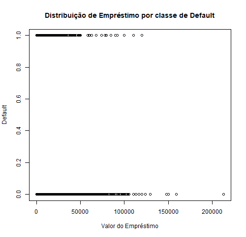

##### B - DEFAULT & MATURIDADE

*Observação: `maturidade` é uma variável que indica quantos dias foram dados para o indivíduo quitar sua dívida, i.e. `maturidade = vencimento - desembolso`*

É possível observar que o há intersecção entre dados para maturidades inferiores a 400 dias. Porém, é possível notar **não** há nenhuma observação de default (i.e. `y = 1`) que para maturidades **superiores** a 400 dias, ou seja, a variável `maturidade` pode ser uma variável significativa para nosso modelo.

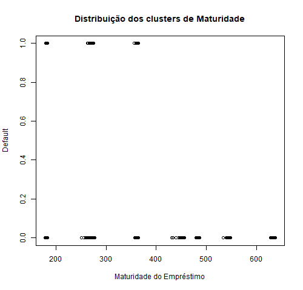

Portanto, a partir dessa análise inicial do dataset bruto, concluímos que será necessário calcularmos variáveis mais relevantes para construirmos um modelo mais robusto de predição de default.

É disso que tratamos na seção a seguir.

## 4 - Data Wrangling

Nesta seção iremos apresentar como foi feita a extração e manipulação de dados e quais são seus significados.

**1. Dados brutos extraídos:**

- `id`
- `valor_emprestado`
- `pgto_diário_esperado`
- `subsegmento`
- `y`
- `desembolso`
- `vencimento`
- `maturidade`: criado a partir de `desembolso` e `vencimento`

**2. Dados Manipulados:**

- `juros_d`: calculados de acordo com a fórmula abaixo e factorizados em 6 classes (`juros_d_nivel`)
  $$juros = \frac{Divida.Total^t - Pagamento.Diario^{t+1}}{Divida.Total^{t+1}}$$
  - `0 - 0.1`
  - `0.10 - 0.15`
  - `0.15 - 0.20`
  - `0.20 - 0.25`
  - `0.25 - 0.30`
  - `0.30+`
    - *Obs.: quando não foi possível calcular a taxa de juros , pois não havia mais do que 1 observação, o `juros_d` desse ID foi computado como 0 a fim de não perder informações sobre este tipo de observação*
- `taxa_t`: calculados de acordo com a fórmula abaixo e factorizados em 7 classes (incluindo `Missing Value` para situações onde nenhuma transação e/ou pagamento foram efetuados e para ID’s com uma única observação).
  $$juros = \frac{Pagamento.Diário^{t+1}}{Transacionado^{t}}$$
  - `0 - 0.05`
  - `0.05 - 0.10`
  - `0.10 - 0.15`
  - `0.15 - 0.20`
  - `0.20 - 0.25`
  - `0.25+`
  - `Missing`
- `diasdepois_pgto`, `diasdepois_trans` e `diasdepois_amort`: mensura quantos dias após o desembolso (dentro de um período de 90 dias), os ID’s performaram o 1º Pagamento, a 1ª Amortização e a 1ª Transação. Dados foram factorizados em 9 classes.
  - `0 - 2`
  - `3 - 5`
  - `6 - 8`
  - `9 - 12`
  - `13 - 15`
  - `16 - 20`
  - `21 - 40`
  - `41 - 90`
  - `Missed 90 days`
- `liq_25`, `liq_50`, `liq_75` e `liq_dia_90`: porcentagem da `dívida_total` liquidada ao final de Q1 (`liq_25`), de Q2 (`liq_50`), de Q3 (`liq_75`) e ao final de 90 dias (`liq_dia_90`)
  - **Valores possíveis - Não Excluídos**:
    - *Número de Observações - [4:89]* : quartis calculados a partir do número de dias disponíveis
      - Exemplo: 10 dias observados - Q1 (dia 3), Q2 (dia 5), Q3 (dia 8) e por fim, dia 10.,
    - *Número de Observações - [3]* : `liq_25` e `liq_50` calculados a partir de 1ª e da 2ª observação, enquanto `liq_75` = ´liq_dia_90`
    - *Número de Observações - [1:2]* : `liq_25` = `liq_50` = `liq_75` = `liq_dia_90`
- `media_pgto_25`, `media_pgto_50`, `media_pgto_75`, `media_pgto_90dias`: média do `pagamento_diario` no quartil Q1, Q2, Q3 e do período de Q3 até 90 dias.
  - **Valores possíveis - Não Excluídos**:
    - ID’s com observações inferiores a 90 dias: quartis calculados a partir do número de dias disponíveis
      - Exemplo: 10 dias observados - Q1 (dia 3), Q2 (dia 5), Q3 (dia 8) e por fim, dia 10.
- `freq_xx_pgto`, `freq_xx_amort` e `freq_xx_trans`: frequência do `pagamento_diario`, `amortizacao_principal_diario` e `transacionado` efetuados em Q1 (i.e. `freq_25_pgto`, `freq_25_amort` e `freq_25_trans`), Q2, Q3 e entre Q3-dias e 90 dias.
  - **Valores possíveis - Não Excluídos**:
    - ID’s com observações inferiores a 90 dias: quartis calculados a partir do número de dias disponíveis
      - Exemplo: 10 dias observados - Q1 (dia 3), Q2 (dia 5), Q3 (dia 8) e por fim, dia 10.

Ao final, o dataset final de treino é gerado contendo todas essas variáveis indicadas anteriormente e armazenadas em um dataset nomeado `train`

```
## # A tibble: 6 x 32
## # Groups:   id [6]
##      id valor_emprestado pgto_diario_esp~ subsegmento y     maturidade
##   <dbl>            <dbl>            <dbl> <chr>       <fct>      <dbl>
## 1     6             7100             33.7 Sem Classi~ 0            276
## 2     8             6900             32.8 Sem Classi~ 0            276
## 3     9            42500            175.  Sem Classi~ 0            276
## 4    11             4200             19.2 Alimentaçã~ 0            276
## 5    12             7700             33.9 Bares e Re~ 0            274
## 6    15             9100             41.6 Autopeças ~ 1            275
## # ... with 26 more variables: pgto_esperado_pp <dbl>,
## #   diasdepois_pgto_nivel <fct>, diasdepois_amort_nivel <fct>,
## #   diasdepois_trans_nivel <fct>, juros_d_nivel <ord>, taxa_t_nivel <ord>,
## #   liq_25 <dbl>, liq_50 <dbl>, liq_75 <dbl>, liq_dia_90 <dbl>,
## #   media_pgto_25 <dbl>, media_pgto_50 <dbl>, media_pgto_75 <dbl>,
## #   media_pgto_90dias <dbl>, freq_25_pgto <dbl>, freq_25_amort <dbl>,
## #   freq_25_trans <dbl>, freq_50_pgto <dbl>, freq_50_amort <dbl>,
## #   freq_50_trans <dbl>, freq_75_pgto <dbl>, freq_75_amort <dbl>,
## #   freq_75_trans <dbl>, freq_90_pgto <dbl>, freq_90_amort <dbl>,
## #   freq_90_trans <dbl>
```

*Observação: É importante ressaltar que a mesma manipulação de dados foi realizada com o arquivo test.parquet, gerando o objeto `test`*

```r
head(test)
```

```
## # A tibble: 6 x 31
## # Groups:   id [6]
##      id valor_emprestado pgto_diario_esp~ subsegmento maturidade
##   <dbl>            <dbl>            <dbl> <chr>            <dbl>
## 1     7             4600             19.3 Calçados           276
## 2    26             3300             13.6 Salão de B~        274
## 3    31             5400             25.9 Outros Ser~        273
## 4    42            14300             68.3 Petshops           274
## 5    48            45900            220.  Autopeças ~        273
## 6    57            10400             47.4 Sem Classi~        276
## # ... with 26 more variables: pgto_esperado_pp <dbl>,
## #   diasdepois_pgto_nivel <fct>, diasdepois_amort_nivel <fct>,
## #   diasdepois_trans_nivel <fct>, juros_d_nivel <ord>, taxa_t_nivel <ord>,
## #   liq_25 <dbl>, liq_50 <dbl>, liq_75 <dbl>, liq_dia_90 <dbl>,
## #   media_pgto_25 <dbl>, media_pgto_50 <dbl>, media_pgto_75 <dbl>,
## #   media_pgto_90dias <dbl>, freq_25_pgto <dbl>, freq_25_amort <dbl>,
## #   freq_25_trans <dbl>, freq_50_pgto <dbl>, freq_50_amort <dbl>,
## #   freq_50_trans <dbl>, freq_75_pgto <dbl>, freq_75_amort <dbl>,
## #   freq_75_trans <dbl>, freq_90_pgto <dbl>, freq_90_amort <dbl>,
## #   freq_90_trans <dbl>
```

# Modelagem

Nesta seção iremos escolher o melhor modelo para indicar no 90º dia qual a probabilidade do cliente não quitar a dívida no prazo e, com base em um cut-off level, indicar sua classificação como default (1) ou non-default (0) dentre dois modelos disponíveis.

O modelo com maior ACU será o escolhido para construir a database `submission.parquet`

## Regressão Logistica

A fim de mensurar a robutez do modelo, iremos dividir a database em duas datasets: `train.train`, a qual treinará o modelo e possui 80% das observações e a `train.test`, a qual será utilizada para testar a acuracidade do modelo.

É importante frisar que após este teste, o dataset que será utilizado para estimar as probabilidades de Default no dataset `test.parquet` será todas as observações de todas as variáveis significativas contidas em `train`.

```r
#Sumário do Dataset Train.Train
dim(train.train)
```

```
## [1] 13876    32
```

```r
#Sumário do Dataset Train.Train
dim(train.test)
```

```
## [1] 3468   32
```

- Passo 1: Verificar variáveis significativas com base no dataset de teste (`train`)

Para descobrir quais parâmetros são realmente valiosos para nossa análise. Utilizando a função `glm` calcularemos o valor-p de cada variável dentro do dataset `train`:

```r
summary(significance)
```

```
##
## Call:
## glm(formula = y ~ ., family = "binomial", data = train)
##
## Deviance Residuals:
##     Min       1Q   Median       3Q      Max
## -1.9023  -0.1908  -0.0654  -0.0077   3.8590
##
## Coefficients:
##                                                         Estimate Std. Error
## (Intercept)                                            1.569e+00  1.222e+02
## id                                                    -9.930e-06  4.006e-06
## valor_emprestado                                       4.725e-05  1.742e-05
## pgto_diario_esperado                                  -9.497e-03  4.146e-03
## subsegmentoAcessórios, Bolsas e Bijuterias            -1.229e+01  2.766e+03
## subsegmentoAlimentação Rápida                          3.430e-01  5.263e-01
## subsegmentoArmarinhos e Tecido                         5.227e-01  7.488e-01
## subsegmentoArtigos de Decoração                       -5.186e-01  1.228e+00
## subsegmentoArtigos Esportivos                         -7.504e-02  8.684e-01
## subsegmentoArtigos Religiosos e Antiguidades          -1.445e+01  2.519e+03
## subsegmentoAssociação                                 -3.187e-01  1.305e+00
## subsegmentoAutopeças e Acessórios                      2.496e-01  5.700e-01
## subsegmentoBares e Restaurantes                        4.620e-01  5.257e-01
## subsegmentoCalçados                                   -1.907e+00  1.155e+00
## subsegmentoCama, Mesa e Banho                         -1.646e-01  1.265e+00
## subsegmentoCasa e Decoração - Outros                   1.155e+01  3.956e+03
## subsegmentoCias Aéreas                                 5.009e+01  3.956e+03
## subsegmentoClinicas de Estética e Massagem            -1.384e-01  6.588e-01
## subsegmentoComércio de Alimentos                       1.910e-01  5.268e-01
## subsegmentoComércio de Bebidas                        -1.773e-02  6.755e-01
## subsegmentoComércio de Veículos                       -2.752e-01  8.719e-01
## subsegmentoConserto de Produtos e Reparos de Peças     5.797e-01  6.793e-01
## subsegmentoConsultorias                                2.520e-01  7.783e-01
## subsegmentoCosméticos e Perfumaria                    -3.973e-01  7.972e-01
## subsegmentoDelivery e Entrega                         -1.271e+01  1.142e+03
## subsegmentoDrogarias e Farmácias                      -6.249e-01  7.244e-01
## subsegmentoEletrodomésticos                            5.047e-01  9.001e-01
## subsegmentoEletrônicos                                -4.183e-02  8.548e-01
## subsegmentoEnsino Básico                              -1.501e+01  1.088e+03
## subsegmentoEnsino Superior e Técnico                   1.788e+01  3.956e+03
```

[output cut: 235 more lines]

```
## freq_75_trans                                           1.205  0.22802
## freq_90_pgto                                            0.443  0.65749
## freq_90_amort                                          -0.402  0.68766
## freq_90_trans                                          -4.738 2.15e-06 ***
## ---
## Signif. codes:  0 '***' 0.001 '**' 0.01 '*' 0.05 '.' 0.1 ' ' 1
##
## (Dispersion parameter for binomial family taken to be 1)
##
##     Null deviance: 6288.1  on 17327  degrees of freedom
## Residual deviance: 3579.0  on 17194  degrees of freedom
##   (16 observations deleted due to missingness)
## AIC: 3847
##
## Number of Fisher Scoring iterations: 16
```

De acordo com a função `glm`, as variáveis que conseguem explicar o comportamento de default dos ID’s (com valor-p mais baixo), são as seguintes (relevamos o fato que a função `glm` indica que a variável ID é significativa):

- `pgto_diario_esperado`
- `valor_emprestado`
- `maturidade`
- `pagamento_esperado_pp`
- `diasdepois_pgto_nivel`
- `diasdepois_trans_nivel`
- `taxa_t_nível`
- `liq_75`
- `media_pgto_25`
- `freq_50_pgto`
- `freq_50_amort`
- `freq_50_trans`
- `freq_90_trans`
- Passo 2: Criar modelo com base no dataset `train.train` somente com variáveis significativas

A partir dessas informações, seremos capazes de construir um modelo que será utilizado para testar a nossa database `train.test`, chamado de `logit_model_train` construído com os dados de `train.train`:

- Passo 3: Prever a probabilidade de que cada ID’s que dará default utilizando o dataset `train.test`

Agora utilizaremos o modelo `logit_model_train` para predizer as probabilidades de default no dataset `train.test`:

- Passo 4: Escolher nível de cut-off para determinar quem dá default (1) e quem quita a dívida dentro do prazo (0)

Escolhendo um cut-off de 15%, obteremos o dataset `pred_cutoff_0.15_train`, com os valores binários de `0` e `1` para os dados `train.test`.

- Passo 5: Comparar os dados previstos com os dados reais e calcular a acuracidade do modelo

```r
#AUC do modelo de Regressão Logistica

round(AUC_logit,3)
```

```
## [1] 0.923
```

## Árvore de Decisão

Agora utilizaremos uma técnica diferente para prever a probabilidade de default no dataset `train.test` e, assim calcular a acuracidade do modelo.

Os passos realizados são semelhantes aos do realizados na seção anterior, “Regressão Logistica”. Por isso, omitimos a explicação do passo-a-passo e observamos apenas os dados de ACU do modelo para os dados de treino e teste (`train.train` e `train.test`).

```r
#AUC do modelo Decision Tree

round(AUC_dt, 3)
```

```
## [1] 0.678
```

# Explicação dos Resultados

Por indicar com alta acuracidade quais clientes que não quitaram a dívida dentro do prazo, o modelo de Regressão Logistica será o utilizado para construir a data base final `submission`.

Para que isso aconteça, repetiremos os Passos 2 e 3 novamente, mas dessa vez utilizaremos os dados do dataset `teste` oriundos do `test.parquet`

A variável que armazenará o modelo se chamará `logit_model` e setando o cut off em 15%, obteremos o dataframe `submission`.

```r
head(submission)
```

```
##   id ypred       yprob
## 1  7     0 0.082566957
## 2 26     0 0.007699397
## 3 31     1 0.280259533
## 4 42     0 0.076119391
## 5 48     0 0.028697882
## 6 57     0 0.024804832
```

Um modelo que é escolhido apenas com base no ACU é um modelo mais frágil.

Por isso, iremos determinar o melhor threshold com base na acuracidade do modelo.

Como apresentado pelo gráfico abaixo, o cutoff de 30% é o que apresenta maior acuracidade. Porém, como o cutoff de 15% é mais conservador e não representa uma queda significativa de acuracidade, iremos utilizar o cut-off de 15% para montarmos nossa dataframe `submission`.

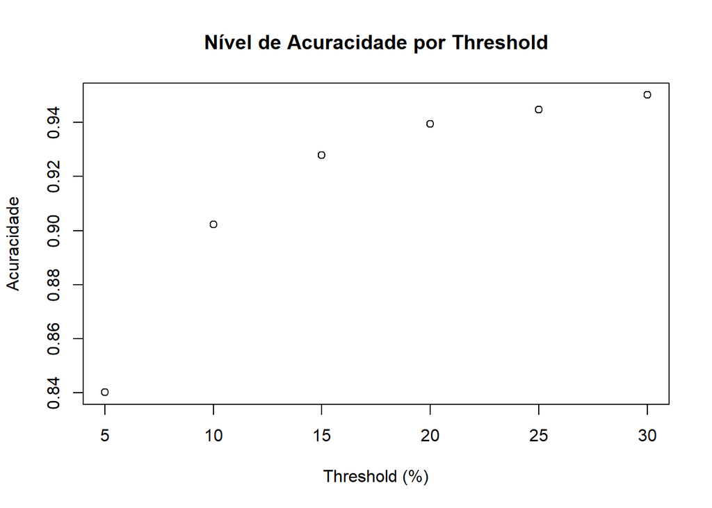